# R Notebook

```r
library(tidyverse)
```

```r
loan <- read_csv("~/Documents/Data Science 2022/Mid Course Project/Data/state_TN_actions_taken.csv")
```

The analysis focuses on loan applications for the purpose of ‘Home Purchase’ (loan_purpose == 1), ‘Not primarily for a business or commercial purpose’ (business_or_commercial_purpose == 2), Occupancy type for the dwelling is “1 - Principal residence”, and all loan type except “Veterans Affairs guaranteed (VA)” (loan_type!=3)

```r
mortgage_loan <- loan %>%
  filter(loan_purpose == 1,
         business_or_commercial_purpose == 2,
         occupancy_type == 1,
         loan_type != 3, applicant_age != "8888") %>%
  mutate(loan_app_denied = ifelse(action_taken==3,1,0)) %>%
  mutate(debt_to_income_group = case_when(
    debt_to_income_ratio == "30%-<36%" ~ "30%-<40%",
    as.numeric(debt_to_income_ratio) %in% 36:39 ~ "30%-<40%",
    as.numeric(debt_to_income_ratio) %in% 40:49 ~ "40%-<50%",
    TRUE ~ debt_to_income_ratio
    ))
```

```r
mortgage_loan_debt_summary <-
  mortgage_loan %>%
  group_by(derived_race, debt_to_income_group) %>%
  summarize(application_count = n()) %>%
  filter(derived_race != "American Indian or Alaska Native" & derived_race != "Native Hawaiian or Other Pacific Islander")
```

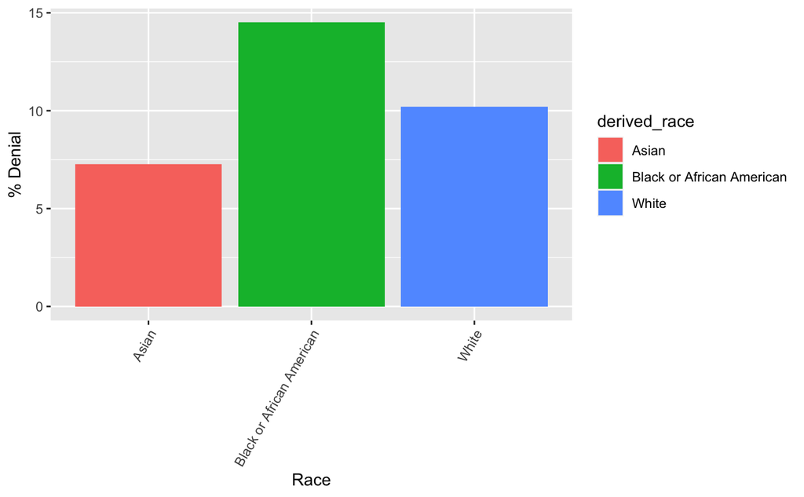

```r
mortgage_loan_summary %>%
  ggplot(aes(x=derived_race, y=pct_denial, fill=derived_race)) +
  geom_col() +
  theme(axis.text.x = element_text(angle = 60, hjust = 1)) +
  scale_x_discrete(name = "Race") +
  scale_y_continuous(name = "% Denial")
```

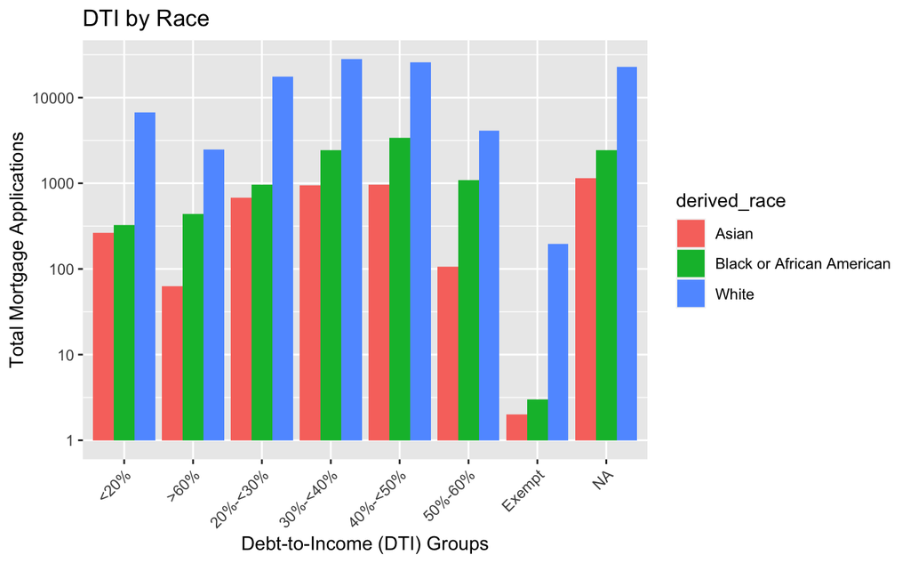

```r
mortgage_loan_debt_summary %>%
  ggplot(aes(y=application_count, x=debt_to_income_group, fill=derived_race)) +
  geom_col(position="dodge") +
  scale_y_continuous(trans = "log10") +
  theme(axis.text.x = element_text(angle = 45, hjust = 1)) +
  xlab("Debt-to-Income (DTI) Groups") +
  ylab("Total Mortgage Applications") +
  ggtitle("DTI by Race")
```

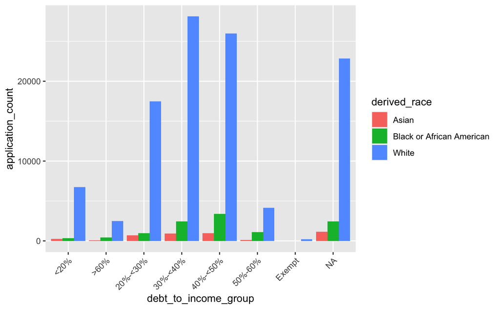

```r
mortgage_loan_debt_summary %>%
  ggplot(aes(y=application_count, x=debt_to_income_group, fill=derived_race)) +
  geom_col(position="dodge") +
  theme(axis.text.x = element_text(angle = 45, hjust = 1))
```

1 - Debt-to-income ratio 2 - Employment history 3 - Credit history 4 - Collateral 5 - Insufficient cash (downpayment, closing costs) 6 - Unverifiable information 7 - Credit application incomplete 8 - Mortgage insurance denied 9 - Other 10 - Not applicable

```r
denial_reasons_count_by_age <-
  mortgage_loan %>%
  select(loan_app_denied, applicant_age, `denial_reason-1`, `denial_reason-2`, `denial_reason-3`, `denial_reason-4`) %>%
  pivot_longer(cols = c(`denial_reason-1`, `denial_reason-2`, `denial_reason-3`, `denial_reason-4`),
               values_to = "denial_reason_code") %>%
  filter(is.na(denial_reason_code)==F, denial_reason_code!=1111, loan_app_denied == 1, applicant_age != ">74") %>%
  group_by(applicant_age, denial_reason_code) %>%
  summarize(denial_reason_count = n()) %>%
  left_join(denial_reasons, by = "denial_reason_code") %>%
  left_join(total_age_denial_count, by = "applicant_age") %>%
  mutate(pct_age_denial = round(100*(denial_reason_count/total_denials_by_age),2))
```

Facet Wrap ggplot % Denial by Race, Age, Sex

[figure not shown]

Facet Wrap ggplot Denial Count By Race, Age, Sex

```r
ggplot(mortgage_loan_denial_reasons) +
    facet_wrap(~derived_race, ncol = 1) +
    #geom_bar(aes(x=factor(denial_reason_text), fill=factor(derived_race)), position="dodge") +
    geom_bar(aes(x=factor(denial_reason_text), fill=factor(derived_race)), show.legend = F) +
    theme(axis.text.x = element_text(angle=60,hjust=1)) +
    scale_x_discrete(name = "Denial Reasons") +
    scale_y_continuous(name = "Denial Frequency")
    #scale_fill_discrete(name = "Race")
```

[output not shown]

```r
mortgage_loan$num_reasons <- apply(mortgage_loan[c("denial_reason-1", "denial_reason-2", "denial_reason-3", "denial_reason-4")], 1,function(x){length(grep(F,is.na(x)))})
```

Logit Model: Age, DTI, Income, Race, Sex

```r
mortgage_loan_glm %>%
  mutate(group=cut(glm_ft_predict_probability, bins)) %>%
  group_by(group) %>%
  summarize(mean_group = mean(loan_app_denied), count_group = count(loan_app_denied)) %>%
  View()
```

```
Error in View : Problem while computing `count_group = count(loan_app_denied)`.
```

Calibration Curve Data

```r
mortgage_loan_glm$glm_ft_predict_probability <-
  predict(glm_ft, mortgage_loan_glm, type = "response")

bins <- seq(from = 0, to = 1, by=0.1)
mortgage_loan_glm %>%
  mutate(group=cut(glm_ft_predict_probability, bins)) %>%
  group_by(group) %>%
  summarize(mean_group = mean(loan_app_denied), count_group = n()) %>%
  View()
```

Test Plot

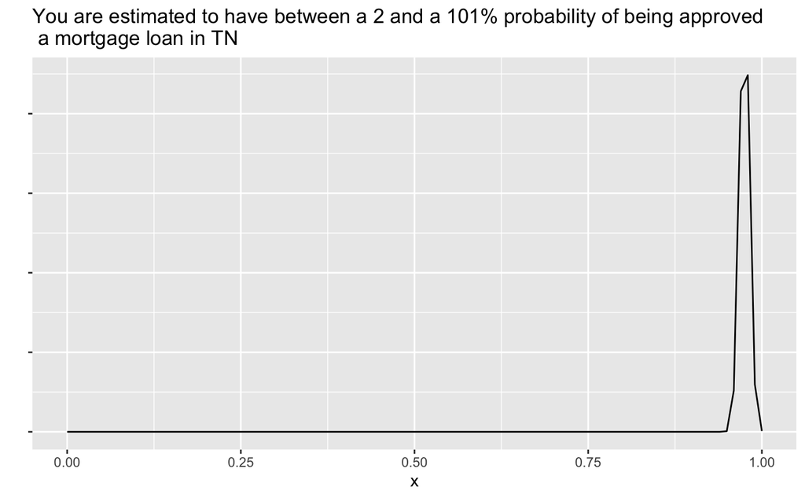

```r
a <- 1-glm_ft_prediction$fit[1]
b <- glm_ft_prediction$se.fit[1]

x <- seq(0,1,length=100)
height <- dnorm(x,a,2*b)

plot_df <- data.frame(x=x,height=height)

ggplot(plot_df, aes(x=x, y=height)) +
  geom_line() +
  scale_y_continuous(name = "", labels = NULL) +
  ggtitle(paste0("You are estimated to have between a ", 100*round(1-(a+b*1.96), digits = 2),
      " and a ", 100*round(1-(x-b*1.96), digits = 2),
      "% probability of being approved\n a mortgage loan in TN"))
```

Create CI for predictions of glm_ft (Logit Model: Age, DTI, Income, Race, Sex)

```r
summary(glm_ft_prediction$fit - glm_ft_prediction$se.fit)
```

```
    Min.  1st Qu.   Median     Mean  3rd Qu.     Max.
0.008503 0.061122 0.088422 0.120844 0.118067 0.980059
```

```r
summary(glm_ft_prediction$fit + glm_ft_prediction$se.fit)
```

```
   Min. 1st Qu.  Median    Mean 3rd Qu.    Max.
0.01057 0.06601 0.09499 0.12850 0.12674 0.98474
```

Logit Model: Age, DTI, Income, Race, Sex, Loan Amount

```r
glm_ft1 <-
  glm(loan_app_denied ~
        factor(applicant_age) + factor(debt_to_income_group) + income + loan_amount +factor(derived_race) +
        factor(derived_sex) -1,
      family = binomial(link = "logit"),
      data = mortgage_loan_glm)
summary(glm_ft1)

mortgage_loan_glm$glm_ft1_predict <-
  ifelse(predict(glm_ft1, mortgage_loan_glm, type = "response") < 0.5, 0, 1)

table(mortgage_loan_glm[c("loan_app_denied","glm_ft1_predict")])
100*table(mortgage_loan_glm$glm_ft1_predict==mortgage_loan_glm$loan_app_denied)/nrow(mortgage_loan_glm)

save(glm_ft1, file = '/Users/thidathornvanitsthian/Documents/Data Science 2022/loan-denial-rate-TN/Data/glm_ft1')
```

[output not shown]

Create CI for predictions of glm_ft1 (Logit Model: Age, DTI, Income, Race, Sex, Loan Amount)

```r
glm_ft1_prediction <-
  predict(glm_ft1, mortgage_loan_glm, type = "response", se.fit = T)

summary(glm_ft1_prediction$fit - glm_ft_prediction$se.fit)
```

```
    Min.  1st Qu.   Median     Mean  3rd Qu.     Max.
-0.01867  0.04306  0.07954  0.12500  0.13829  0.98990
```

```r
summary(glm_ft1_prediction$fit + glm_ft_prediction$se.fit)
```

```
    Min.  1st Qu.   Median     Mean  3rd Qu.     Max.
0.007054 0.049763 0.087408 0.132655 0.147371 1.018838
```

Income is significant by itself

```r
glm_income <-
  glm(loan_app_denied ~ income,
      family = binomial(link = "logit"),
      data = mortgage_loan_glm)
summary(glm_income)
```

```
Call:
glm(formula = loan_app_denied ~ income, family = binomial(link = "logit"),
    data = mortgage_loan_glm)

Deviance Residuals:
    Min       1Q   Median       3Q      Max
-0.8683  -0.5861  -0.4779  -0.3217   2.9199

Coefficients:
              Estimate Std. Error z value Pr(>|z|)
(Intercept) -0.7637585  0.0222843  -34.27   <2e-16 ***
income      -0.0175120  0.0003322  -52.71   <2e-16 ***
---
Signif. codes:  0 ‘***’ 0.001 ‘**’ 0.01 ‘*’ 0.05 ‘.’ 0.1 ‘ ’ 1

(Dispersion parameter for binomial family taken to be 1)

    Null deviance: 75563  on 100448  degrees of freedom
Residual deviance: 72067  on 100447  degrees of freedom
AIC: 72071

Number of Fisher Scoring iterations: 5
```

```r
confint(glm_income)
```

```
                  2.5 %      97.5 %
(Intercept) -0.80742248 -0.72006733
income      -0.01816584 -0.01686343
```

```r
glm_income_predict <-
  predict(glm_income, mortgage_loan_glm)

mortgage_loan_glm$glm_income_predict <-
  ifelse(predict(glm_income, mortgage_loan_glm, type = "response") < 0.5, 0, 1)


100*table(mortgage_loan_glm$glm_income_predict==mortgage_loan_glm$loan_app_denied)/nrow(mortgage_loan_glm)
```

```
   FALSE     TRUE
12.46702 87.53298
```

```r
glm_race <-
  glm(loan_app_denied ~ factor(derived_race),
      family = binomial(link = "logit"),
      data = mortgage_loan_glm)
summary(glm_race)
```

```
Call:
glm(formula = loan_app_denied ~ factor(derived_race), family = binomial(link = "logit"),
    data = mortgage_loan_glm)

Deviance Residuals:
    Min       1Q   Median       3Q      Max
-0.7113  -0.5070  -0.5070  -0.5070   2.1687

Coefficients:
                                                              Estimate Std. Error z value Pr(>|z|)
(Intercept)                                                    -1.2454     0.1152 -10.808  < 2e-16
factor(derived_race)Asian                                      -1.0061     0.1320  -7.624 2.46e-14
factor(derived_race)Black or African American                  -0.3757     0.1184  -3.173  0.00151
factor(derived_race)Native Hawaiian or Other Pacific Islander  -0.6035     0.2852  -2.116  0.03435
factor(derived_race)White                                      -0.7413     0.1157  -6.408 1.48e-10

(Intercept)                                                   ***
factor(derived_race)Asian                                     ***
factor(derived_race)Black or African American                 **
factor(derived_race)Native Hawaiian or Other Pacific Islander *
factor(derived_race)White                                     ***
---
Signif. codes:  0 ‘***’ 0.001 ‘**’ 0.01 ‘*’ 0.05 ‘.’ 0.1 ‘ ’ 1

(Dispersion parameter for binomial family taken to be 1)

    Null deviance: 75563  on 100448  degrees of freedom
Residual deviance: 75360  on 100444  degrees of freedom
AIC: 75370

Number of Fisher Scoring iterations: 4
```

```r
confint(glm_race)
```

```
                                                                   2.5 %      97.5 %
(Intercept)                                                   -1.4761855 -1.02398442
factor(derived_race)Asian                                     -1.2619367 -0.74412583
factor(derived_race)Black or African American                 -0.6036044 -0.13891077
factor(derived_race)Native Hawaiian or Other Pacific Islander -1.1918124 -0.06733798
factor(derived_race)White                                     -0.9636354 -0.50960528
```

```r
glm_race_predict <-
  predict(glm_race, mortgage_loan_glm)

mortgage_loan_glm$glm_race_predict <-
  ifelse(predict(glm_race, mortgage_loan_glm, type = "response") < 0.5, 0, 1)

save(glm_race, file = '/Users/thidathornvanitsthian/Documents/Data Science 2022/loan-denial-rate-TN/Data/glm_race')

100*table(mortgage_loan_glm$glm_race_predict==mortgage_loan_glm$loan_app_denied)/nrow(mortgage_loan_glm)
```

```
   FALSE     TRUE
12.46702 87.53298
```

```r
glm_DTI <-
  glm(loan_app_denied ~ factor(debt_to_income_group),
      family = binomial(link = "logit"),
      data = mortgage_loan_glm)
summary(glm_DTI)
```

```
Call:
glm(formula = loan_app_denied ~ factor(debt_to_income_group),
    family = binomial(link = "logit"), data = mortgage_loan_glm)

Deviance Residuals:
    Min       1Q   Median       3Q      Max
-2.1506  -0.4398  -0.4177  -0.4069   2.2505

Coefficients:
                                     Estimate Std. Error z value Pr(>|z|)
(Intercept)                          -1.79924    0.03819  -47.11   <2e-16 ***
factor(debt_to_income_group)>60%      4.00752    0.07182   55.80   <2e-16 ***
factor(debt_to_income_group)20%-<30% -0.59601    0.04651  -12.81   <2e-16 ***
factor(debt_to_income_group)30%-<40% -0.65040    0.04330  -15.02   <2e-16 ***
factor(debt_to_income_group)40%-<50% -0.48806    0.04262  -11.45   <2e-16 ***
factor(debt_to_income_group)50%-60%   0.70025    0.04708   14.87   <2e-16 ***
---
Signif. codes:  0 ‘***’ 0.001 ‘**’ 0.01 ‘*’ 0.05 ‘.’ 0.1 ‘ ’ 1

(Dispersion parameter for binomial family taken to be 1)

    Null deviance: 75563  on 100448  degrees of freedom
Residual deviance: 63876  on 100443  degrees of freedom
AIC: 63888

Number of Fisher Scoring iterations: 5
```

```r
confint(glm_DTI)
```

```
                                          2.5 %     97.5 %
(Intercept)                          -1.8747753 -1.7250462
factor(debt_to_income_group)>60%      3.8682715  4.1498682
factor(debt_to_income_group)20%-<30% -0.6868471 -0.5045144
factor(debt_to_income_group)30%-<40% -0.7348160 -0.5650437
factor(debt_to_income_group)40%-<50% -0.5711013 -0.4040181
factor(debt_to_income_group)50%-60%   0.6083217  0.7928929
```

```r
glm_DTI_predict <-
  predict(glm_DTI, mortgage_loan_glm)

mortgage_loan_glm$glm_DTI_predict <-
  ifelse(predict(glm_DTI, mortgage_loan_glm, type = "response") < 0.5, 0, 1)


100*table(mortgage_loan_glm$glm_race_predict==mortgage_loan_glm$loan_app_denied)/nrow(mortgage_loan_glm)
```

```
   FALSE     TRUE
12.46702 87.53298
```